# IDG_2026 S-1

## Trabajo 2: Microsimulación y agrupamiento de zonas censales

# "Afiliados a FONASA: dónde, cómo y por qué se distribuyen en el Gran Santiago"

#### Profesor: Matías Escudero Bell

#### Estudiante: Gabriel González Belaúnde

..............................................................................................................................................................................................................................................................................................................

# INTRODUCCIÓN

Junto al Censo, la Casen (Encuesta de Caracterización Socioeconómica Nacional) es uno de los estudios estadiísticos más relaventes de Chile. Este instrumento permite al Estado determinar, por ejemplo, la distribución de ingresos, condiciones de vida, caracterización de salud, pero por sobre todo para medir la pobreza en sus múltiples dimensiones. Toda esta información (que termina por constituirse como una aproximación a la descripción socioeconómica del país), sirve como base para la elaboración de diversas políticas públicas y mejoras en el gasto social (Vera & Alvear, 2026); una buena encuesta (considerando su confección metodológica y cómo es que termina por llevarse a cabo) conduce a una mejor focalización de los recursos públicos y con ello mejorar el bienestar de la sociedad. En otras palabras, contar con este tipo de instrumentos resulta clave para la administración del país.

No obstante, la información publicada sobre la Casen por el Ministerio de Desarrollo Social (ente elaborador) está presentada de forma regional, es decir, que los resultados de cantidades, índices o porcentajes se tienen a nivel regional. Esto supone un desafío si lo que se desea es ahondar en el comportamiento de estas variables a una escala más detallada, como lo puede ser a nivel comunal o de manzana. Ante esto, lo que se procede a realizar es una denominada "microsimulación espacial", con la que considerando datos regionales y por medio de regresiones de múltiples variables, es posible reproducir de una forma aproximada el comportamiento del fenómeno estudiado disgregándolo espacialmente a una escala menor deseada.

En el presente informe, se estudia el cómo se distribuye espacialmente en el Gran Santiago la pertenencia al sistema previsional público de salud: FONASA. Para ello se trabaja con información pública disponible en la Encuesta Casen 2024 la que por el hecho de detallarse a nivel regional, se microsimula a nivel de zona censal. Esto último dado que además se analizan los comportamientos en la misma área de estudio de variables asociables disponibles en el Censo 2024; en específico, el nivel de personas que presentan dificultades para moverse y la cantidad de personas con estudios superiores también por zona censal. Todo esto con el fin de establecer cómo es que estas tres variables están relacionadas entre sí, con lo cual se pueden determinar además ciertos patrones territoriales en las comunas del Gran Santiago.

La movilidad reducida (o dismovilidad) es una condición física de las personas que va en aumento. La dismovilidad se ha definido como disminución de la capacidad para movilizarse de forma independiente desde una localización a otra, así como el descenso de la capacidad de realizar actividades de la vida diaria, por deterioro de funciones motoras (Oyarzún, 2020). Esta situación se ha tornado cada vez frecuente en el país considerando que Chile se encuentra en un período de transición demográfica hacia un envejecimiento poblacional (González, 2026). Al 2023, el 45,6% de las personas mayores (1.573.005) presenta algún tipo de problema para poder caminar y/o subir las escaleras (FG, 2023). Relacionar espacialmente este fenómeno al alza con el de la ubicación de los afiliados a FONASA, permite develar desafíos de cara al futuro para la institución en el sentido de que deben prever las necesidades y urgencias de sus clientes así como de los que demandarán por su servicio en años venideros.

Actualmente en Chile se encuentra bajo discusión el modelo de cobertura de salud, siendo la Ley 21.674 del 2024 un punto de inflexión al respecto. A raíz de ciertos cambios en la normativa vigente, se espera que en el mediano plazo, FONASA empiece a recibir clientes hasta ahora afiliados a Isapres (Rebolledo, 2023). Esto supondría un cambio en la distribución espacial de los amparados por FONASA, constituyendo a este análisis en un antecedente con el cual comparar y determinar dónde es que se terminan dando principalmente dichos cambios en el Gran Santiago.

# OBJETIVOS

Objetivo General:

- Analizar el comportamiento espacial así como de la interralación que puedan tener la distribución de los afiliados a FONASA, las personas con dismovilidad y quienes ostenten estudios superiores en el Gran Santiago.

Objetivos Específicos:

- Realizar una microsimulación espacial de los afiliados a FONASA según los datos de la Casen 2024 para las zonas censales del Gran Santiago.
- Comparar la distribución de la microsimulación obtenida con el comportamiento territorial de la ubicación de las personas con dismovilidad y de aquellos que posean estudios superiores en base a los datos del Censo 2024.
- Revisar la bibliografía disponible relacionada a los fenómenos estudiados en el Gran Santiago.
- Establecer el grado de interrelación entre las variables analizadas mediante la incorporación de un agrupamiento por K-Means, junto con interpretar las implicancias que pueden tener la dinámica de las variables estudiadas en el Gran Santiago.

# METODOLOGÍA

El siguiente estudio inicia definiendo al área urbana del Gran Santiago como la zona de estudio. En total, 36 comunas son las que serán estudiadas a nivel de zona censal. De ellas, 32 son correspondientes a la Provincia de Santiago (la totalidad de ésta) más las comunas de San Bernardo, Puente Alto, Pirque y Padre Hurtado.

Posteriormente, la variable seleccionada perteneciente a la Encuesta Casen 2024 trata sobre el nivel de afiliación a FONASA. Además, el estudio consideró, para efectos de comparación e interpretación, las variables referentes la cantidad de personas con dismovilidad y al porcentaje de personsa con estudios superiores; ambas con información extraída desde el Censo del 2024 y considerando las cifras a nivel de zona censal. Con todo, lo que se busca determinar es el grado de interrelación territorial de estas variables, y establecer si acaso la actuación de alguna variable en particular incide más que el resto a tal punto de influir en su comportamiento. En concreto, analizar la dismovilidad de la población resulta significativo para comprobar si este factor guarda relación con el grado de afiliación a FONASA (lo que se sabe que va de la mano con el nivel socioeconómico), lo cual a su vez, en caso de que exista una correlación positiva entre estas, conduce a una referencia para la institución sobre una característica de sus clientes. Del mismo modo, se espera que quienes cuenten con estudios superiores (y por ende un mejor nivel socioeconómico) desistan de pertenecer a FONASA buscando las mejores prestaciones que otorga el sistema privado de las Isapres.

En definita, la construcción de las variables es:

## --------------------------------------------------------------------------------

### - Porcentaje de afiliados a FONASA en el Gran Santiago

```
Considerando las respuestas de la pregunta “s13” de la Encuesta Casen 2024 sobre a qué sistema previsional de salud se pertenece, se toma en cuenta a aquellos que respondieron que al Sistema Público FONASA (1), quedando:

% afiliados a FONASA = (s13/P)*100
	Sea
s13 = 1 (es decir, FONASA)
P = Población total por zona censal del Gran Santiago
```

## --------------------------------------------------------------------------------

### - Cantidad de personas con dismovilidad en el Gran Santiago

```
Corresponde al número de personas que afirmaron en el Censo 2024 presentar algún grado de dificultad para moverse como por ejemplo al caminar o al subir escaleras, cuya cifra corresponde a la variable "n_dificultad_mover". Así:

N° de personas con dismovilidad = n_dificultad_mover
```

## --------------------------------------------------------------------------------

### - Porcentaje de personas con estudios superiores en el Gran Santiago

[output not shown]

## --------------------------------------------------------------------------------

Luego de definir las variables a estudiar, el manejo de datos inició por su recopilación desde sitios oficiales donde se albergan los resultados del Censo 2024 y de la Encuesta Casen del mismo año. Estos datos fueron trabajados usando lenguaje Python ya sea para la filtración de estos, la microsimulación de la variable de afiliación a FONASA, y así como para la confección de mapas y gráficos. Este estudio considera la elaboración de mapas de cómo se comportan por separado en la zona de estudio las variables mencionadas, para luego realizar la aplicación del método K-Means para comprobar el grado de interrelación entre estas. Todo el detalle se muestra en el siguiente apartado del Desarrollo.

Por otro lado se realizó una breve revisión bibliográfica referente a temas recientes del área de salud que den cuenta de cómo es que varían los fenómenos estudiados en el territorio del Gran Santiago.

# DESARROLLO

#### 1) Área de estudio

El Gran Santiago corresponde a la mayor área urbana del país. La extensión territorial del Gran Santiago es tal, que abarca comunas más allá de la Provinicia de Santiago, motivo por el cual se termina incluyendo a San Bernardo, Puente Alto, Pirque y Padre Hurtado para poder considerar al área urbana de forma fehaciente. Poder estudiar las dinámicas territoriales que en ella se desarrollan es comprender cómo la mitad de la población de Chile interactúa. En rigor, el área de estudio de este trabajo comprende a 6.248.056 habitantes. La gran mayoría de los afiliados a FONASA (el 80% de la población) se concentra en el Gran Santiago (Orellana, 2024), por lo que poder estudiar su comportamiento junto con el de otras variables demógraficas permite revelar interacciones subyacentes del modelo de salud, y que a su vez sirva de antecendete ante los cambios a implementar (Rebolledo, 2023) en dicho modelo.

#### 2) Carga y manejo de datos

Primero que todo, se instalan y cargan las siguientes librerías:

```python
! pip install pyreadr
! pip install contextily
! pip install ipfn
```

```python
import os

os.environ.pop('PROJ_LIB', None)
os.environ.pop('PROJ_DATA', None)
os.environ.pop('GDAL_DATA', None)

from sqlalchemy import create_engine
from sklearn.linear_model import LinearRegression
import pandas as pd
import geopandas as gpd
import matplotlib.pyplot as plt
from matplotlib.lines import Line2D
import seaborn as sns
import mapclassify
import numpy as np
import pyreadr
import contextlib
import io
import warnings
import mapclassify
import contextily as cx
from ipfn import ipfn
import matplotlib.patheffects as pe
from sklearn.preprocessing import StandardScaler
from sklearn.cluster import KMeans

sns.set_theme(style="whitegrid")
```

```python
ruta_casen = "../DATA/CASEN24/casen_rm.rds"
ruta_censo_comunal = "../DATA/CENSO24/Cartografía_censo2024_R13/Cartografía_censo2024_R13_Comunal.parquet"
ruta_censo_zonal = "../DATA/CENSO24/Cartografía_censo2024_R13/Cartografía_censo2024_R13_Zonal.parquet"
```

```python
casen_raw = pyreadr.read_r(ruta_casen)
casen_raw = casen_raw[list(casen_raw.keys())[0]]
```

```python
censo_zonal = gpd.read_parquet(ruta_censo_zonal)
# Se abre y filtra la base de datos censal para el área de estudio:
gs = (censo_zonal["PROVINCIA"] == 'SANTIAGO') | (
    censo_zonal["COMUNA"].isin(['SAN BERNARDO', 'PUENTE ALTO', 'PIRQUE', 'PADRE HURTADO'])
)
censo_zonal = censo_zonal[gs].reset_index(drop=True)
```

#### 3) Microsimulación

```python
# Lo primero es definir a la variable que se busca simular junto a las variables explicativas (VARS_FIJAS)
casen_raw["s13_es_1"] = (casen_raw["s13"] == 1).astype(int)
VARS_FIJAS =  ["estrato", "esc", "e6a", "edad", "sexo",
               "v13", "v13_propia", "v13_arrendada", "v13_cedida"]

# Ahora asignamos la nueva columna como la variable a microsimular
VARIABLE_A_MICROSIMULAR = "s13_es_1"
FUNCION_AGREGACION = np.mean
vars_a_cargar = VARS_FIJAS + [VARIABLE_A_MICROSIMULAR]

# Se acota la CASEN únicamente a las variables a utilizar
casen = casen_raw[vars_a_cargar].copy()
casen["comuna"] = (casen["estrato"]//100).astype("Int64")
casen = casen.drop(columns = "estrato")
comunas_gs = censo_zonal["CUT"].unique()
casen = casen[casen["comuna"].isin(comunas_gs)].reset_index(drop=True)
```

```python
# Luego se debe hacer calzar el Censo con la Casen, debiendo renombrar las columnas:
ZONA_ID = "OBJECTID"

COLS_SEXO = {"hombre": "n_hombres", "mujer": "n_mujeres"}
COLS_EDAD = {
    "edad_0_5": "n_edad_0_5",
    "edad_6_13": "n_edad_6_13",
    "edad_14_17": "n_edad_14_17",
    "edad_18_24": "n_edad_18_24",
    "edad_25_44": "n_edad_25_44",
    "edad_45_59": "n_edad_45_59",
    "edad_60_mas": "n_edad_60_mas",
}
COLS_EDUC = ["educ_nunca", "educ_primaria", "educ_secundaria", "educ_terciaria"]
COLS_TENENCIA = {
    "ten_propia_pagada": "n_tenencia_propia_pagada",
    "ten_propia_pagandose": "n_tenencia_propia_pagandose",
    "ten_arrendada_contrato": "n_tenencia_arrendada_contrato",
    "ten_arrendada_sin_contrato": "n_tenencia_arrendada_sin_contrato",
    "ten_cedida_trabajo": "n_tenencia_cedida_trabajo",
    "ten_cedida_familiar": "n_tenencia_cedida_familiar",
    "ten_otro": "n_tenencia_otro",
}

constraints = censo_zonal[[ZONA_ID, "CUT", "COMUNA", "n_per", "n_hog"]].copy()
for nombre,col in {**COLS_SEXO, **COLS_EDAD}.items():
    constraints[nombre] = censo_zonal[col]

constraints["educ_nunca"] = censo_zonal["n_cine_nunca_curso_primera_infancia"]
constraints["educ_primaria"] = (censo_zonal["n_cine_primaria"] +
                               censo_zonal["n_cine_especial_diferencial"])
constraints["educ_secundaria"] = censo_zonal["n_cine_secundaria"]
constraints["educ_terciaria"] = censo_zonal["n_cine_terciaria_maestria_doctorado"]

# Se calculan personas por hogar:
personas_por_hogar = np.where(
    censo_zonal["n_hog"] > 0, censo_zonal["n_per"] / censo_zonal["n_hog"], 0
)
for nombre, col in COLS_TENENCIA.items():
    constraints[nombre] = censo_zonal[col] * personas_por_hogar

# Y por último se ordenan las categorías:
CATEGORIAS = {
    "sexo_cat": list(COLS_SEXO.keys()),
    "edad_cat": list(COLS_EDAD.keys()),
    "educ_cat": COLS_EDUC,
    "tenencia_cat": list(COLS_TENENCIA.keys()),
}

constraints = constraints.set_index(ZONA_ID)

# También es necesario imputar la variable "esc" según "e6a", debiendo hacerse un regresión lineal para ello
falta_esc = casen["esc"].isna()

modelo_esc = LinearRegression().fit(
    casen.loc[~falta_esc, ["e6a"]], casen.loc[~falta_esc, "esc"]
)
pred = modelo_esc.predict(casen.loc[falta_esc, ["e6a"]])
casen.loc[falta_esc, "esc"] = np.clip(np.round(pred), 0, 20)

# Luego además se genera una semilla para asegurar una correcta simulación
SEED = 727
```

```python
# Recodificación de categorías del censo

## Sexo
casen["sexo_cat"] = casen["sexo"].map({1: "hombre", 2: "mujer"})

## Edad
casen["edad_cat"] = pd.cut(
    casen["edad"],
    bins=[0, 6, 14, 18, 25, 45, 60, np.inf],
    labels=list(COLS_EDAD.keys()),
    right=False,
    include_lowest=True,
).astype(str)

## Educación
casen["educ_cat"] = pd.cut(
    casen["esc"],
    bins=[-1, 0, 8, 12, np.inf],
    labels=COLS_EDUC,
).astype(str)

## Tenencia de vivienda
condiciones = [
    (casen["v13"] == 1) & (casen["v13_propia"] == 1),
    (casen["v13"] == 1) & (casen["v13_propia"] == 2),
    (casen["v13"] == 2) & (casen["v13_arrendada"] == 5),
    (casen["v13"] == 2) & (casen["v13_arrendada"] == 6),
    (casen["v13"] == 3) & (casen["v13_cedida"] == 7),
    (casen["v13"] == 3) & (casen["v13_cedida"] == 8),
]
categorias_tenencia = [
    "ten_propia_pagada",
    "ten_propia_pagandose",
    "ten_arrendada_contrato",
    "ten_arrendada_sin_contrato",
    "ten_cedida_trabajo",
    "ten_cedida_familiar",
]
casen["tenencia_cat"] = np.select(condiciones, categorias_tenencia, default="ten_otro")

casen["ID"] = np.arange(len(casen))

# sin la variable a microsimular, la persona no puede ser "donante"
sin_valor = casen[VARIABLE_A_MICROSIMULAR].isna()
print(f"Personas excluidas del pool de donantes por {VARIABLE_A_MICROSIMULAR} faltante: {sin_valor.sum()}")
casen = casen[~sin_valor].reset_index(drop=True)

casen[["comuna", "sexo_cat", "edad_cat", "educ_cat", "tenencia_cat", VARIABLE_A_MICROSIMULAR, "ID"]]


# Finalmente se lleva a cabo el proceso para reponderar "IPF":
def pesos_por_persona(seed, codigos, celda_a_personas):

    dims = [[i] for i in range(len(codigos["objetivos"]))]
    IPF = ipfn.ipfn(
        seed.copy(),
        codigos["objetivos"],
        dims,
        convergence_rate=1e-6,   # qué tan exacto debe quedar el ajuste
        max_iteration=50,        # tope de vueltas si no converge antes
    )
    tabla_reponderada = IPF.iteration()  # arreglo del mismo tamaño que seed
    peso_celda = tabla_reponderada[codigos["indices"]]
    return peso_celda / celda_a_personas

# Junto al proceso para reponderar "IPF", se integra:
def integerise_trs(pesos, rng):
    parte_entera = np.floor(pesos).astype(int)
    parte_fraccionaria = pesos - parte_entera
    idx = np.arange(len(pesos))
    replicados = np.repeat(idx, parte_entera)
    n_total = int(round(pesos.sum()))
    n_faltante = n_total - parte_entera.sum()

    if n_faltante > 0 and parte_fraccionaria.sum() > 0:
        probs = parte_fraccionaria / parte_fraccionaria.sum()
        extra = rng.choice(idx, size=n_faltante, replace=True, p=probs)
        replicados = np.concatenate([replicados, extra])

    return replicados

# Acá se termina de microsimular:
rng = np.random.default_rng(SEED)

VARS_CONSTRAINT = list(CATEGORIAS.keys())  # ["sexo_cat", "edad_cat", "educ_cat", "tenencia_cat"]

resultados_zona = []
zonas_sin_donantes = []

buffer_salida = io.StringIO()
with contextlib.redirect_stdout(buffer_salida), warnings.catch_warnings():
    warnings.simplefilter("ignore", RuntimeWarning)

    for comuna_cut, cons_comuna in constraints.groupby("CUT"):
        muestra_comuna = casen[casen["comuna"] == comuna_cut]

        if len(muestra_comuna) == 0:
            zonas_sin_donantes.extend(cons_comuna.index.tolist())
            continue

        indices = {
            var: pd.Categorical(muestra_comuna[var], categories=CATEGORIAS[var]).codes
            for var in VARS_CONSTRAINT
        }
        forma = tuple(len(CATEGORIAS[var]) for var in VARS_CONSTRAINT)
        seed_tabla = np.zeros(forma)
        indices_tupla = tuple(indices[var] for var in VARS_CONSTRAINT)
        np.add.at(seed_tabla, indices_tupla, 1)
        celda_a_personas = seed_tabla[indices_tupla]  # cuántas personas comparten la celda de cada persona

        valores_objetivo = muestra_comuna[VARIABLE_A_MICROSIMULAR].to_numpy()

        for zona_id, fila in cons_comuna.iterrows():
            if fila["n_per"] == 0:
                continue

            objetivos = [
                np.array([fila[cat] for cat in CATEGORIAS[var]], dtype=float)
                for var in VARS_CONSTRAINT
            ]

            pesos = pesos_por_persona(
                seed_tabla, {"objetivos": objetivos, "indices": indices_tupla}, celda_a_personas
            )
            sinteticos_idx = integerise_trs(pesos, rng)

            valores_sinteticos = valores_objetivo[sinteticos_idx]

            resultados_zona.append({
                "zona_id": zona_id,
                "CUT": comuna_cut,
                "n_sintetico": len(sinteticos_idx),
                "n_censo": fila["n_per"],
                "valor_zona": FUNCION_AGREGACION(valores_sinteticos) if len(valores_sinteticos) else np.nan,
            })

resultados_zona = pd.DataFrame(resultados_zona).set_index("zona_id")
print(f"Zonas simuladas: {len(resultados_zona)}")
print(f"Zonas sin comuna con donantes CASEN: {len(zonas_sin_donantes)}")
```

```
Personas excluidas del pool de donantes por s13_es_1 faltante: 0
Zonas simuladas: 1656
Zonas sin comuna con donantes CASEN: 0
```

[figure not shown]

```python
# Por último se grafica la microsimulación en el área de estudio con el siguiente mapa:

zonas_mapa = censo_zonal.set_index(ZONA_ID).join(resultados_zona[["valor_zona"]]) # Para agregar un mapa base
if zonas_mapa.crs is None:
    zonas_mapa.set_crs(epsg=4326, inplace=True)

fig, ax = plt.subplots(figsize=(10, 10))
zonas_mapa.plot(
    column="valor_zona",
    cmap="Grays",
    linewidth=0.3,
    edgecolor="grey",
    alpha=0.7,
    legend=True,
    legend_kwds={'label': "Porcentaje de personas afiliadas a FONASA", 'shrink': 0.6},
    missing_kwds={"color": "lightgrey", "label": "sin dato"},
    ax=ax,
)

comunas_limites = censo_zonal.dissolve(by='COMUNA')
comunas_limites.plot(ax=ax, facecolor='none', edgecolor='white', linewidth=1.2)
cx.add_basemap(ax, crs=zonas_mapa.crs.to_string(), source=cx.providers.CartoDB.Positron) # Se agrega mapa base

ax.set_title("Microsimulación de afiliados a FONASA por zona censal\nGRAN SANTIAGO - CASEN 2024")
ax.set_axis_off()
plt.show()
```

#### 4) Variables adicionales

```python
# Acá se confeccionan las variables deseadas:
porcentaje_superiores_2024 = (censo_zonal["n_cine_terciaria_maestria_doctorado"] / censo_zonal["n_per"]) * 100
dismovilidad = censo_zonal["n_dificultad_mover"]
```

[figure not shown]

```python
# Este bloque genera los mapas para visualizar el comportamiento espacial de las variables adicionales provenientes de la información censal del 2024.
def plot_univariado(ax, censo_zonal_z, censo_zonal_c, censo_zonal_ct, col, cmap, titulo, cbar_label):
    censo_zonal_z.plot(
        column=col, ax=ax, cmap=cmap,
        linewidth=0.13, edgecolor='#333',
        legend=True,
        legend_kwds={'label': cbar_label, 'shrink': 0.4, 'pad': 0.02}
    )
    censo_zonal_c.plot(ax=ax, facecolor='none', edgecolor='#111', linewidth=1.4)
    for _, row in censo_zonal_ct.iterrows():
        ax.annotate(
            row.name,
            xy=(row.geometry.x, row.geometry.y),
            ha='center', va='center',
            fontsize=9, fontweight='bold', color='#111',
            bbox=dict(boxstyle='round,pad=0.2', fc='white', alpha=0.65, ec='none')
        )
    ax.set_title(titulo, fontsize=19, fontweight='bold', pad=10)
    ax.grid(True, linestyle='--', alpha=0.6)

    x, y, arrow_length = 0.08, 0.95, 0.08   # Flecha norte
    ax.annotate('N',
                xy=(x, y),
                xytext=(x, y - arrow_length),
                arrowprops=dict(facecolor='black', edgecolor='black', width=3, headwidth=10, headlength=12),
                ha='center', va='center',
                fontsize=22, fontweight='bold', color='black',
                xycoords='axes fraction', textcoords='axes fraction')

    ax.set_xlabel('Longitud', fontsize=18)
    ax.set_ylabel('Latitud', fontsize=18)
    ax.tick_params(axis='x', rotation=45, labelsize=13)
    ax.tick_params(axis='y', labelsize=13)
    cx.add_basemap(ax, crs=censo_zonal_z.crs.to_string(), source=cx.providers.CartoDB.Positron)    # Acá se añade un mapa base

if 'SHAPE' in censo_zonal.columns:
    censo_zonal = censo_zonal.set_geometry('SHAPE').rename_geometry('geometry')
if censo_zonal.crs is None:
    censo_zonal.set_crs(epsg=4326, inplace=True)
else:
    censo_zonal = censo_zonal.to_crs(epsg=4326)

censo_zonal['porcentaje_superiores_2024'] = (censo_zonal['n_cine_terciaria_maestria_doctorado'] / censo_zonal['n_per']) * 100
censo_zonal['dismovilidad'] = censo_zonal['n_dificultad_mover']

censo_zonal_comunas = censo_zonal.dissolve(by='COMUNA')
censo_zonal_centroides = censo_zonal_comunas.copy()
censo_zonal_centroides.geometry = censo_zonal_comunas.geometry.centroid

fig, axes = plt.subplots(1, 2, figsize=(23, 20))
fig.patch.set_facecolor('#fafafa')

plot_univariado(
    axes[0], censo_zonal, censo_zonal_comunas, censo_zonal_centroides,
    'porcentaje_superiores_2024', 'Purples', # Mapa para las personas con estudios superiores
    '% Personas con estudios superiores por zona censal \nGran Santiago - CENSO 2024',
    '% Personas con estudios superiores'
)
plot_univariado(
    axes[1], censo_zonal, censo_zonal_comunas, censo_zonal_centroides,
    'dismovilidad', 'Oranges', # Mapa para las personas con dismovilidad
    'N° de personas con dismovilidad por zona censal \nGran Santiago - CENSO 2024',
    'N° de personas con dismovilidad'
)

plt.tight_layout(pad=2)
plt.show()
```

#### 5) Clustering

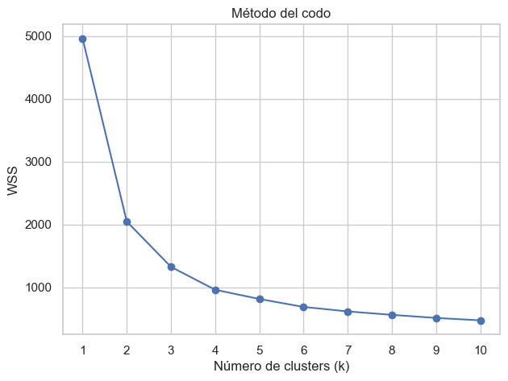

```python
# Lo primero es asegurarse de usar los datos correctos
usable = (censo_zonal['n_per'] > 0) & (censo_zonal['n_dificultad_mover'] > 0)

censo_zonal = censo_zonal[usable].reset_index(drop=True)

# Se genera una base de datos con la que se pueda clusterizar que incluye la variable proveniente desde la CASEN y las otras 2 desde el CENSO
censo_zonal['valor_zona_simulado'] = censo_zonal['OBJECTID'].map(resultados_zona['valor_zona'])
censo_zonal['porcentaje_superiores_2024'] = (censo_zonal['n_cine_terciaria_maestria_doctorado'] / censo_zonal['n_per']) * 100
censo_zonal['dismovilidad'] = censo_zonal['n_dificultad_mover']
censo_zonal['porcentaje_afiliados_fonasa'] = censo_zonal['valor_zona_simulado']

indicadores = ['porcentaje_superiores_2024', 'dismovilidad', 'porcentaje_afiliados_fonasa'] # estas son las variables a escalar

# Escalamiento por zona censal:

ezc = censo_zonal[indicadores] # Se escalan las variables dado que puede pasar que las variables se encuentren en rangos muy distintos.
escalador = StandardScaler()
ezc_escalado = escalador.fit_transform(ezc)

# Luego de escalar se aplica el Método del Codo:
wss = []
valores_k = range(1, 11)

for k in valores_k:
    modelo = KMeans(n_clusters=k, n_init=25, random_state=SEED)
    modelo.fit(ezc_escalado)
    wss.append(modelo.inertia_)

plt.figure(figsize=(7, 5))
plt.plot(valores_k, wss, marker="o")
plt.title("Método del codo")
plt.xlabel("Número de clusters (k)")
plt.ylabel("WSS")
plt.xticks(list(valores_k))
plt.show()
```

```python
# En base a lo obtenido con el Método del Codo, se establece que el K óptimo = 4:
K = 4

kmeans = KMeans(n_clusters=K, n_init=25, random_state=SEED)
censo_zonal["cluster"] = kmeans.fit_predict(ezc_escalado).astype(str)
censo_zonal["cluster"].value_counts().sort_index() # Para ver cúantos elementos (zonas censales) tiene cada clúster
```

```
cluster
0    242
1    446
2    626
3    340
Name: count, dtype: int64
```

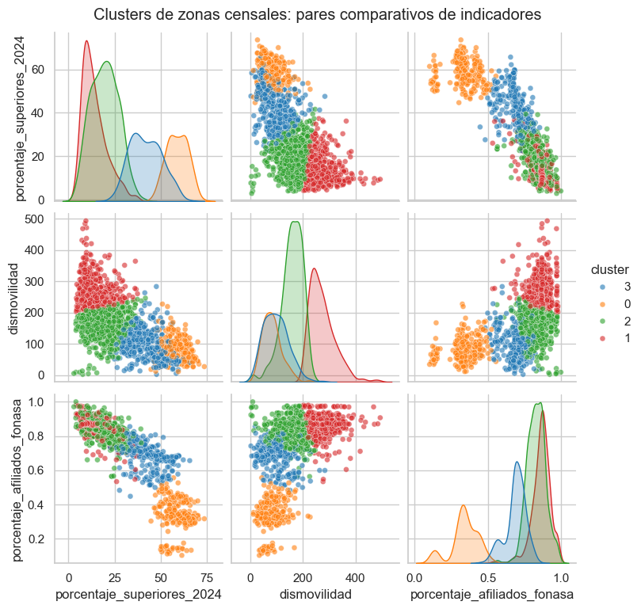

```python
# Acá se muestran las relaciones entre las 3 variables estudiadas:
sns.pairplot(
    censo_zonal,
    vars=indicadores,
    hue="cluster",
    palette="tab10",
    plot_kws={"alpha": 0.6, "s": 25},
    diag_kind="kde",
)
plt.suptitle("Clusters de zonas censales: pares comparativos de indicadores", y=1.02)
plt.show()
```

```python
# naranjos (0): alto porcentaje de educación superior; bajo nivel de dismovilidad; bajo porcentaje de afiliados en FONASA
# rojos (1): bajo porcentaje de educación superior; alto nivel de dismovilidad; alto porcentaje de afiliados en FONASA
# verdes (2): bajo porcentaje de educación superior; medio nivel de dismovilidad; alto porcentaje de afiliados en FONASA
# azules (3): medio porcentaje de educación superior; bajo nivel de dismovilidad; medio-alto porcentaje de afiliados en FONASA

# En base a lo obtenido, se renominan los clúster para una mejor comprensión:
renominar = {
    "0": "Ilustrados, Sist. salud privado y Sanos",
    "1": "Vulnerables, mayoría FONASA y Alta Dismovilidad",
    "2": "Clase media, mayoría FONASA y Media Dismovilidad",
    "3": "Emergentes, FONASA medio-alto y Sanos"
}

# Aplicamos el renombre en la columna 'cluster'
censo_zonal["cluster"] = censo_zonal["cluster"].map(renominar)

# Verificamos los nuevos nombres
censo_zonal["cluster"].value_counts()
```

```
cluster
Clase media, mayoría FONASA y Media Dismovilidad    626
Vulnerables, mayoría FONASA y Alta Dismovilidad     446
Emergentes, FONASA medio-alto y Sanos               340
Ilustrados, Sist. salud privado y Sanos             242
Name: count, dtype: int64
```

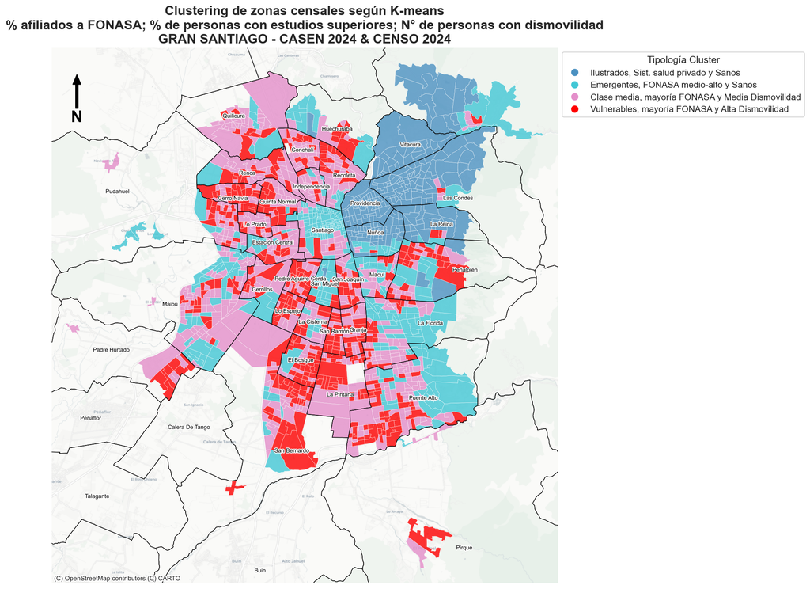

```python
# Lo último a realizar es mapear los clusters en el siguiente mapa:

comunas_geometria = gpd.read_parquet(ruta_censo_comunal)
nombre_geom = comunas_geometria.geometry.name
if censo_zonal.crs is None:
    censo_zonal.set_crs(epsg=4326, inplace=True)

# Se establecen colores específicos para cada clúster:
colores_especificos = {
    "Ilustrados, Sist. salud privado y Sanos": "#4B91C1",             # Azul oscuro
    "Emergentes, FONASA medio-alto y Sanos": "#42C7D5",               # Cyan / Celeste
    "Clase media, mayoría FONASA y Media Dismovilidad": "#E48FCA",    # Rosa
    "Vulnerables, mayoría FONASA y Alta Dismovilidad": "#FF0000"      # Rojo
}

fig, ax = plt.subplots(figsize=(12, 12), dpi=150)
censo_zonal.plot(
    color=censo_zonal["cluster"].map(colores_especificos),
    linewidth=0.3,
    edgecolor="white",
    alpha=0.8,
    ax=ax
)

legend_elements = [
    Line2D([0], [0], marker='o', color='w', label=k, markerfacecolor=v, markersize=10)
    for k, v in colores_especificos.items()
]
ax.legend(handles=legend_elements, title="Tipología Cluster", loc="upper left", bbox_to_anchor=(1, 1))

comunas_geometria.boundary.plot(ax=ax, color="black", linewidth=0.6)
for _, fila in comunas_geometria.iterrows():
    punto = fila[nombre_geom].representative_point()
    ax.annotate(
        fila["COMUNA"].title(),
        xy=(punto.x, punto.y),
        ha="center", va="center",
        fontsize=7, color="black",
        path_effects=[pe.withStroke(linewidth=2, foreground="white")],
    )

cx.add_basemap(ax, crs=censo_zonal.crs.to_string(), source=cx.providers.CartoDB.Positron, zoom=12) # Se añade mapa base
x, y, arrow_length = 0.05, 0.95, 0.08                                                              # Se añade Flecha Norte
ax.annotate('N',
            xy=(x, y),
            xytext=(x, y - arrow_length),
            arrowprops=dict(facecolor='black', edgecolor='black', width=3, headwidth=10, headlength=12),
            ha='center', va='center',
            fontsize=20, fontweight='bold', color='black',
            xycoords='axes fraction', textcoords='axes fraction')
ax.set_title("Clustering de zonas censales según K-means\n% afiliados a FONASA; % de personas con estudios superiores; N° de personas con dismovilidad\nGRAN SANTIAGO - CASEN 2024 & CENSO 2024", fontsize=16, fontweight='bold')
ax.set_axis_off()

xmin, ymin, xmax, ymax = censo_zonal.total_bounds
margen_x = (xmax - xmin) * 0.03
margen_y = (ymax - ymin) * 0.03
ax.set_xlim(xmin - margen_x, xmax + margen_x)
ax.set_ylim(ymin - margen_y, ymax + margen_y)

plt.show()
```

#### 6) Variabilidad intra-comunal

```python
# Para finalizar el análisis llevado a cabo, a continuación se aplica el Índice de Shannon a la zona de estudio.
# El Índice de Shannon mide y sirve para mostrar el grado de variabilidad dentro de un espacio dado.
# En este caso se busca determinar qué tan variable es cada comuna respecto a la interrelación de las 3 variables estudias,
# es decir, qué tan homogéneo o heterogéneo es una comuna, considerando los clusters que posea y caracteriza.
```

## --------------------------------------------------------------------------------

### - Índice de Shannon (H)

[output not shown]

## Se considera que un número cercano a 0 representa una baja variabilidad de la zona, mientras que por el contrario, a mayor Índice de Shannon, mayor diversidad (variabilidad).

## --------------------------------------------------------------------------------

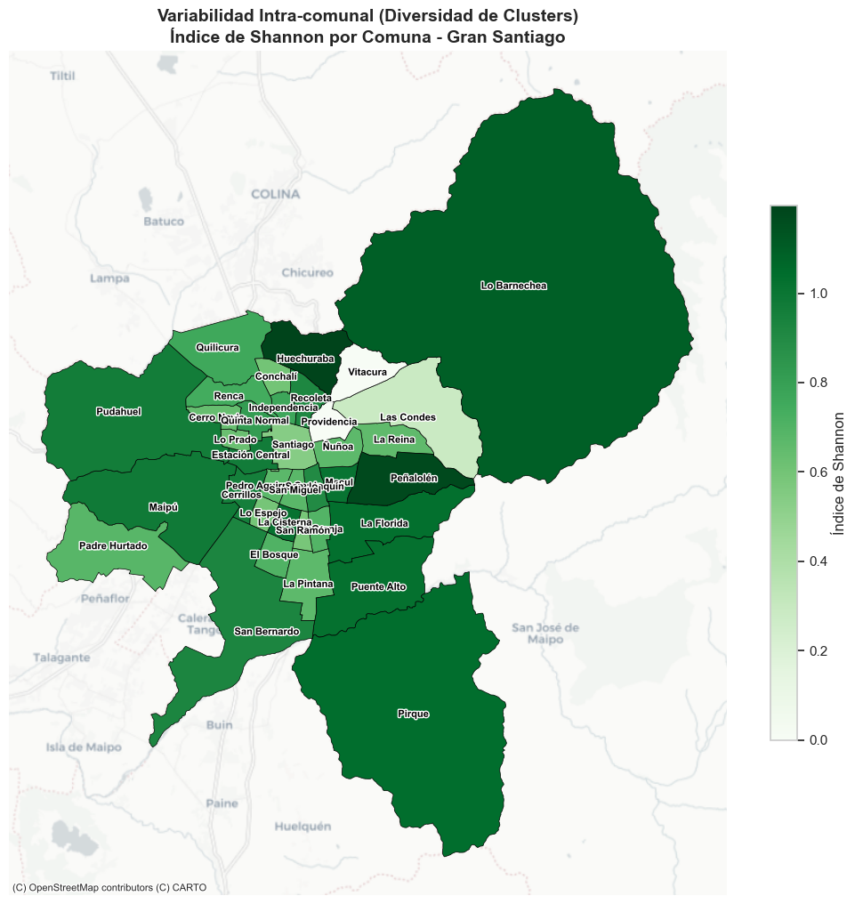

```python
# A continuación se detalla el proceso para elaborar el Índice de Shannon con etiquetas:
def shannon_index(series):
    proporciones = series.value_counts(normalize=True)
    return -np.sum(proporciones * np.log(proporciones))

# Cálculo del Índice por comuna:
shannon_comunal = censo_zonal.groupby('COMUNA')['cluster'].apply(shannon_index).reset_index()
shannon_comunal.columns = ['COMUNA', 'shannon_index']
comunas_mapa = comunas_geometria.merge(shannon_comunal, on='COMUNA')

# Mapa:
fig, ax = plt.subplots(figsize=(13, 13))
comunas_mapa.plot(
    column='shannon_index',
    cmap='Greens',
    legend=True,
    edgecolor='black',
    linewidth=0.5,
    legend_kwds={'label': "Índice de Shannon", 'shrink': 0.6},
    ax=ax
)

# Etiquetas:
nombre_col_geo = comunas_mapa.geometry.name
for _, fila in comunas_mapa.iterrows():
    punto = fila[nombre_col_geo].representative_point()
    ax.annotate(
        text=fila["COMUNA"].title(),
        xy=(punto.x, punto.y),
        ha="center",
        va="center",
        fontsize=8,
        fontweight='bold',
        color="black",
        path_effects=[pe.withStroke(linewidth=2, foreground="white")]
    )

cx.add_basemap(ax, crs=comunas_mapa.crs.to_string(), source=cx.providers.CartoDB.Positron)      # Se añade mapa base
ax.set_title("Variabilidad Intra-comunal (Diversidad de Clusters)\nÍndice de Shannon por Comuna - Gran Santiago", fontsize=14, fontweight='bold')
ax.set_axis_off()

plt.show()
```

# Análisis y discusión

Para los efectos de este análisis se debe considerar que el Fondo Nacional de Salud (FONASA) es el seguro público de salud de Chile y una de las principales encargadas de financiar el acceso a la atención de salud de la población, brindando cobertura a más de 17 millones de personas en Chile recaudando, admnistrando y distribuyendo los recursos provenientes principalmente de la cotización obligatoria del 7% de los ingresos de los trabajadores (Goyenechea & Aylwin, 2026); garantizando el acceso a la salud sin discriminación por edad, género, situación económica, nacionalidad o condición de salud.

Antes de abordar el grado de interrelación observado entre las variables estudiadas, corresponde mencionar el comportamiento espacial de cada una de estas. Así, se puede mencionar que la distribución de los porcentajes de personas afiliadas a FONASA en las zonas censales se caracteriza por una mayor concentración de estos fuera del sector nororiente del Gran Santiago, particularmente con una mayor prescencia en las comunas del sector norte y sur de la capital. En general, la Avenida Vicuña Mackenna se presenta como un verdadero límite que diferencia entre los sectores con más y menos porcentaje de afiliados a FONASA en la zona de estudio.

Por otro lado, una distribución similar aunque más marcado incluso en las comunas del sector sur posee la cantidad de personas con dismovilidad. En todo caso, en ciertas zonas de Quilicura, Renca, San Bernardo y Maipú se aprecia una baja considerable de personas con dismovilidad aún cuando se trata de sectores con gran tasa de clientes de FONASA. Esto puede explicarse con que se trata de barrios industriales, donde la gente puede tratarse de personas más activas.

Por último, así como las dos variables anteriores mostraban grandes similitudes respecto a su distribución, el comportamiento espacial del porcentaje de personas con estudios superiores es totalmente distinto: se concentran en comunas del sector oriente (Las Condes, Providencia, Vitacura, Lo Barnechea con partes de La Reina y Ñuñoa), es decir, donde el porcentaje de afiliados a FONASA es por lo general bajo. Mientras, en el sector poniente sólo predominan porcentajes medios en ciertas zonas de comunas puntuales, tales como San Miguel, Huechuraba, La Florida y Maipú.

Ahora bien, en cuanto a la clusterización se debe considerar que se generaron sólo 4 clúster para la agrupación dado que según el Método del Codo, se estima que dicho valor era el óptimo. Dicho esto, y al analizar la interrelación entre las 3 variables por medio de los gráficos de dispersión y comportamiento de las variables comparadas entre sí, se denota una clara correlación negativa en la comparación entre variables salvo en la del nivel de dismovilidad según el % de afiliados a FONASA. Luego se observa claramente 4 tipos de comportamiento distintos que hacen que sea consecuente la división entre esta cantidad de clústers. También cabe señalar que el clúster de "Ilustrados, Sist. privado de salud y sanos" son los de menor número, siendo la mitad y un tercio aproximadamente de las personas vulnerables y de clase media, respectivamente.

El análisis de forma más detallada en el territorio desde luego que nos proporciona una mejor información acerca de los fenómenos sociales que se dan en éste. A partir de estos resultados, y dado la mejor calidad de la información, se pueden desarrollar y promover iniciativas que faciliten la integración de los grupos más vulnerables de la sociedad de una mejor forma. Entre ellas, autores (Larraín, 2021) han mencionado como ejemplo las buenas condiciones de transporte y de acceso a actividades resulta esencial considerando el ámbito social y de salud. Ello supone una mejor focalización de los no precisamente abundantes recursos públicos, algo bastante deseable tomando en cuenta el gran gasto en materia de salud (Matus & Pedraza, 2026) que existe en Chile, por lo que optimizar aquello es absolutamente necesario.

Cabe mencionar que sería prudente en otra investigación analizar el factor de la edad. Esto permitiría ahondar en el detalle de también el perfil socioeconómico de estos y, además serviría de comparación contra las cifras de la Organización Mundial de la Salud (OMS) quienes han descrito que un 20% de los mayores de 70 años y un 50% de los mayores de 85 años presentan algún nivel de limitación del movimiento a causa de caídas, infecciones urinaria, osteoporosis, osteoartritis, deficiencias vitamínicas, demencia, entre otros motivos (Oyarzún, 2020), de tal manera que dicha comparación mostraría la realidad del Gran Santiago versus el promedio mundial al respecto.

# Conclusiones

Respecto a las correlaciones entre las variables estudiadas, y más allá del lugar donde estas se estén dando, se estima que por lo general el nivel educacional (en este caso de niveles superiores) se desliga absolutamente del hecho de pertenecer a FONASA: queda claro que la mayor parte de sus afiliados no cuentan mayoritariamente con estudios superiores. Con la variable que sí guarda relación es con la dismovilidad, donde se observa que aquellas personas con estudios superiores en promedio no se caracterizan por tener grandes niveles de dismovilidad. Caso contrario ocurre con las personas clientes de FONASA donde se aprecia una correlación positiva bastante marcada.

De todas maneras, se concluye que es necesario contraponer estos comportamientos de las variables vistas con otras no analizadas. Esto dado que, si bien se observan estos patrones y correlación que inducen a concluir que existe una marcada interrelación entre estas variables, el hecho de compararlas con otras más podría fortalecer y reafirmar a estos patrones observados: correlación no implica causalidad, por lo que si lo que se busca es zanjar en definitiva la dependencia que existe entre un fenómeno y otro, lo mejor es proseguir con aún más comparaciones al respecto.

Se concluye que estos estudios que detallan aún más el comportamiento de distintos fenómenos constituyen verdaderas bases sobre la cual se pueden focalizar de mejor forma la asignación de recuros monetarios.

Finalmente, respecto al presente trabajo, se estima que estudios como éste son relevantes para una mejor comprensión de los fenómenos sociales en el territorio. Para ello es nesario contar con el dominio de lenguajes de programación para el manejo de grandes cantidades de datos, por lo cual, y entendiendo que análisis como estos son de gran utitildad para el servicio público, se recomienda el acercamiento de estas tecnologías a sus funcionarios.

# Bibliografía

- FD. (2023). Más de 10 mil personas mayores que tienen dificultad para moverse, concentrarse, vestirse y comunicarse no cuentan con nadie que los ayude. *Facultad de Gobierno de la Universidad del Desarrollo, Chile.*
- González, L. (2026). Cambio demográfico en Chile. *Diálogos Urbanos de la CChC, Chile.*
- Goyenechea, M. & Aylwin, A. (2026). Seguros complementarios y gasto en la Modalidad de Libre Elección de Fonasa. *Center for Open Science, Estados Unidos.*
- Larraín, C. & Tiznado, I. (2021). Análisis de los criterios para definir áreas de integración urbana en Chile. *Revista de Urbanismo, Chile.*
- Matus-López, M., & Cid Pedraza, C. (2026). Financiamiento de la salud en Chile: análisis histórico y de largo plazo del sistema segmentado: 1981–2024 *Cuadernos Médico Sociales, Chile.*
- Orellana, C., *et al*. (2024). Construyendo una Atención Primaria eficaz: Análisis de la situación acutal de las APS en Chile, experiencia y recomendaciones internacionales para fortalecer y mejorar la estrategia de APS Universal. *Instituto de Salud Pública de la Universidad Andrés Bello, Chile.*
- Oyarzún, F., *et al*. (2020). Trastornos de la movilización y la marcha en personas mayores: Aproximación desde la atención primaria de salud (APS). *Revista Chilena de Medicina Familiar, Chile.*
- Rebolledo, C. (2023). Otras perspectivas acerca del asunto de las Isapres. *Cuaderno Médica Social, Chile.*
- Vera, B. & Alvear, S. (2026). Determinantes sociales que influyen en las enfermedades cardiovasculares en personas mayores de 60 años y más, según Casen 2022. *Revista Médica de Chile, Chile.*